# A3: Incarceration

### Introduction

In this assignment, I will be exploring the disparities between different genders in the rates of incarceration. This can allow us to better understand any gender-based discrimination in the justice system by looking at to what extent the proportion of males and females differ in jail across the country.

### Summary Information

From my findings, I found that the number of males in prison greatly differ from the number of females in prison. The total amount of males in prison in the most recent date in 2018 is 6.2014802^{5} (620148) people, compared to 1.0383795^{5} (103837.9) of females. The year with the highest male in prison is 2008 of 6.8061372^{5} (680613.7) males. The year with the highest female in prison is 2018 of 1.0383795^{5} (103837.9) females. The average change (increase) in number of each gender to go to jail is 9907.3333333 for males and 2001.6866667 for females.

### The Dataset

The Incarceration Trends data was created by Vera Institute of Justice, which reports on the county and jurisdiction level jail data from 1970- 2018 and prison data 1983-2016. The extensive research and grants allow the data to cover a wide variety of incarceration trends nationwide and across many years, as well as continuing updates in recent years. Vera also continued to update the data set with additional research and grants. The dataset was collected because research on incarceration has traditionally been centered on state level data and they wanted find data that was more robust by finding the county-level variability in incarceration rates in the US and unpack many more of its causes and consequences.

There are 153,811 observations in this data, with findings across 121 features. An ethical consideration is that any findings derived from interpreting or visualizing this data set would only be a correlation, that one must be careful in making assumptions about the entire population based on a result. Incarceration is a very sensitive subject that considers a wide range of topics like gender, race, region, demographics that could vary greatly amongst many different individuals. A limitation of the data set is the number of unknown values there are present in the data, either due to uncertainty in data-collection over decades ago, or in remote areas with little amount of data on incarceration. This is can alter the accuracy of some of the values calculated as NA values would be omitted from overall calculations.

### Trends Over Time Chart

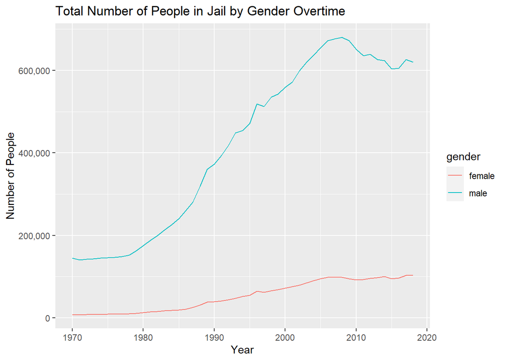

This table shows the difference in trend of the number of male and female in jail from 1970-2018

#### Purpose

By looking at the trends in numbers of male and female in jail, we can see the disparities between genders in incarceration rates, and derive possible reasons for this difference over the years. Understanding the trend in number of people in jail over the years can also allow us to derive possible events in each year that may influences rates of incarcerations and further explain gender disparities.

#### Insights

- Females always have a much lower number of people in prison compared to males. Overtime, this gap between the genders widen, with the highest difference around 2007 and 2008
- Number of females in Jail has slowly and gradually increase over the years, with only around over 100,000 in jail in 2018
- Number of males however has rapidly increased over the year, peaking around 2007-2008 and falling back down in the years after.

### Variable Comparison Chart

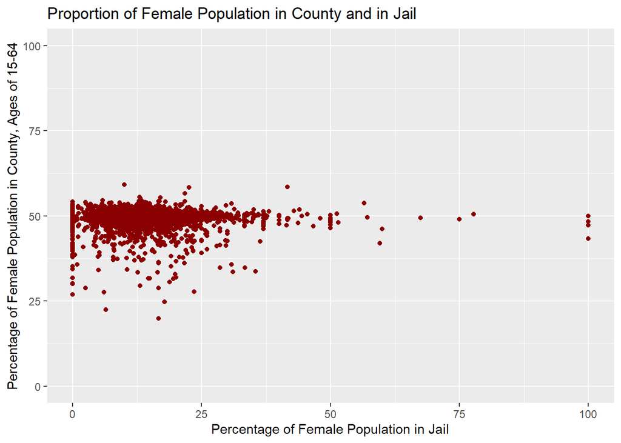

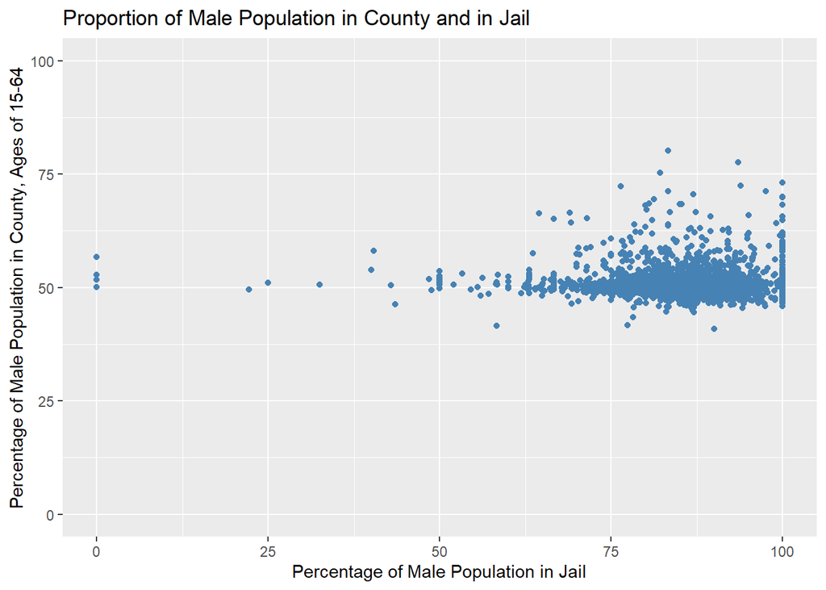

Scatter plots showing the relationship of proportion of the **overall county population** that female/male and proportion of female/male population **in jail**.

#### Purpose

By deriving the overall population proportion of each gender in the county and comparing it to the proportion of each gender in jail, we can see if any increase/decrease in a gender in jail would just simply be due to an overall increase in that gender in the total county population. This would therefore not be due to disparities caused by the different genders.

#### Insights

- Although the majority of the counties had equal numbers of males and female population, there were more counties that had a higher proportion of males of ages between 15-64.
- The two variables (% from population of each gender and % of each gender in jail) were not quite correlated, percentage of people in jail had significantly higher numbers of males than female, even with counties that had equal numbers of male and female.

### Map

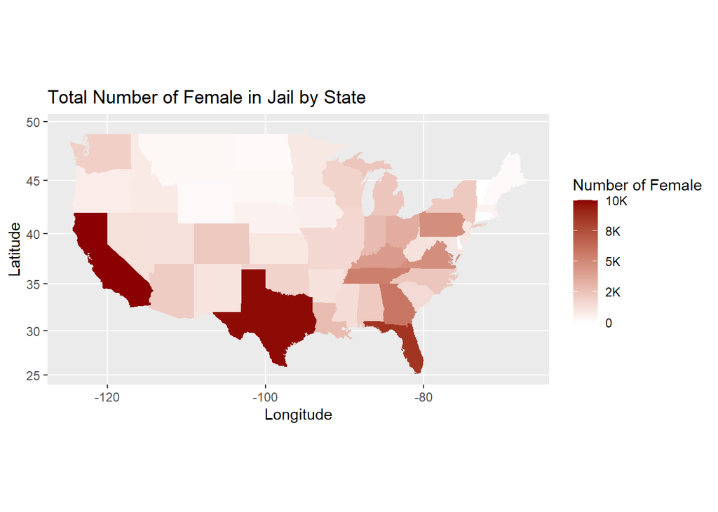

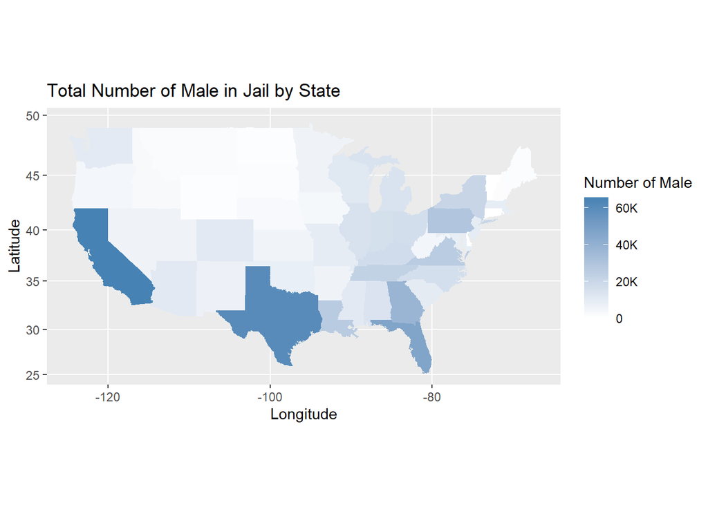

#### Purpose

These maps compares total number of males and females across each states. Firstly, by looking at the differences in numbers of people in jail by state, we can understand which states has high amounts of incarceration and those who have low amounts. From this, find possible reasons for these differences by looking at local events and crimes that are renowned in these states. I also created separate maps for male and female to find out whether there are any differences in gender in incarceration in each state, and potentially conduct additional research on why these differences occur.

#### Insights

- States with large populations like California and Texas has the highest number of both male and female in jail. High population in this case would probably be the reason for the high number of people in jail overall.
- There were not many differences in male and female numbers in jail across the different state. There were differences in some Midwestern and Southern states like Ohio, Kentucky and Tennessee. Any other differences are very subtle.